# Analysis scripts

# 1 Introduction

This documentation contains the core analysis script for the manuscript:  
“Accounting for differences between Infinium MethylationEPIC v2 and v1 in DNA methylation-based tools”

Preprint is available at https://www.biorxiv.org/content/10.1101/2024.07.02.600461v2

*Please note that the example data only consisted for a small subset of probes and samples. The full dataset will be available for public access soon.

```r
# save(EPICv1_beta_matrix,EPICv2_beta_matrix,EPICv1_clocks, EPICv2_clocks,SampleInfo,file = "example_data.Rdata")

load( "example_data.Rdata")
head(EPICv1_beta_matrix)
```

```
##            12125-V_v1 12157-V_v1 11112-V_v1 12294-V_rep_v1 12172-V_v1
## cg00000029  0.4835882  0.5428022  0.5986397      0.5206964  0.6358705
## cg00000109  0.9013099  0.8965594  0.9028244      0.8833679  0.8882210
## cg00000155  0.9303012  0.9258365  0.9367663      0.9341097  0.9288309
## cg00000158  0.9521107  0.9380483  0.9342822      0.9408431  0.9384601
## cg00000165  0.1341092  0.1363907  0.2515770      0.1368004  0.1718296
## cg00000221  0.8816435  0.8717790  0.8745818      0.8786665  0.8371999
##            12144-V_v1 12242-V_v1 12106-V_v1 12180-V_v1 12054-V_v1 12294-V_v1
## cg00000029 0.51780192  0.5394581  0.6167817  0.6604567  0.5331109 0.55051175
## cg00000109 0.88711573  0.8776513  0.8944121  0.8881039  0.8905556 0.88186086
## cg00000155 0.93233837  0.9232522  0.9272306  0.9304704  0.9294171 0.93203121
## cg00000158 0.94094946  0.9398857  0.9408496  0.9386611  0.9434243 0.93702361
## cg00000165 0.08665448  0.1588597  0.1134778  0.1023657  0.1326873 0.09813962
## cg00000221 0.84163394  0.8585126  0.8637497  0.8616145  0.8674241 0.87743420
##            12185-V_v1 12150-V_v1 12024-V_v1 12104-V_v1 12109-V_v1 12123-V_v1
## cg00000029  0.5645559  0.5565734  0.5859823  0.6307797  0.5973507  0.6214518
## cg00000109  0.8872266  0.8690468  0.8790717  0.8845878  0.9005653  0.8956690
## cg00000155  0.9259383  0.9217437  0.9248875  0.9315774  0.9313477  0.9299366
## cg00000158  0.9398965  0.9352963  0.9423992  0.9432765  0.9474824  0.9459607
## cg00000165  0.2149458  0.1256303  0.2127693  0.1171282  0.3964342  0.1322903
## cg00000221  0.8645205  0.8341127  0.8421656  0.8752967  0.8453939  0.8453663
##            12112-V_v1 12116-V_v1 12196-V_v1 11008-V_v1 12124-V_v1 12110-V_v1
## cg00000029  0.7132084  0.4841036 0.42841938  0.6709731  0.6545159  0.7089268
## cg00000109  0.8891311  0.8993216 0.89851077  0.8758229  0.8888294  0.8915059
## cg00000155  0.9317445  0.9233182 0.93002890  0.9259287  0.9219354  0.9232815
## cg00000158  0.9391860  0.9319935 0.93694763  0.9365877  0.9342969  0.9445639
## cg00000165  0.1661010  0.2214990 0.05928519  0.1127189  0.1231755  0.1432054
## cg00000221  0.8501839  0.8612164 0.85978398  0.8722428  0.8654595  0.8737614
##            12242-V_rep_v1
## cg00000029      0.5068063
## cg00000109      0.8662641
## cg00000155      0.9278387
## cg00000158      0.9389348
## cg00000165      0.1660373
## cg00000221      0.8650633
```

```r
head(EPICv2_beta_matrix) # with replicate probes collapsed, and probe names are ILLUMINA NAME, same as in EPICv1
```

```
##            12125-V_v2 12157-V_v2 11112-V_v2 12294-V_rep_v2 12172-V_v2
## cg00000029  0.3802876  0.4285545  0.4676056      0.4759210  0.5034532
## cg00000109  0.8951054  0.8997027  0.8820914      0.9046184  0.9281236
## cg00000155  0.9369879  0.9107133  0.9266212      0.9203335  0.9385676
## cg00000158  0.9463728  0.9435156  0.9423631      0.9488340  0.9460779
## cg00000165  0.1409703  0.1258470  0.2550715      0.1851148  0.1571206
## cg00000221  0.8632246  0.8929719  0.8984173      0.8616686  0.8399926
##            12144-V_v2 12242-V_v2 12106-V_v2 12180-V_v2 12054-V_v2 12294-V_v2
## cg00000029 0.38008727  0.4683143  0.4867868  0.5218932  0.4374645  0.4643437
## cg00000109 0.90325683  0.9092939  0.9064535  0.9184560  0.9185976  0.8888865
## cg00000155 0.92318600  0.9361216  0.9282784  0.9275336  0.9179588  0.9341778
## cg00000158 0.92604882  0.9501093  0.9462053  0.9383005  0.9453282  0.9431774
## cg00000165 0.07791678  0.1997483  0.1458067  0.1519161  0.1082854  0.1089577
## cg00000221 0.86570826  0.8752341  0.8947523  0.8928873  0.8913909  0.8622792
##            12185-V_v2 12150-V_v2 12024-V_v2 12104-V_v2 12109-V_v2 12123-V_v2
## cg00000029  0.5152386  0.4273830  0.5311976 0.46852824  0.5064906  0.5968688
## cg00000109  0.9153867  0.9108442  0.9183908 0.91725554  0.9136761  0.9087943
## cg00000155  0.9190959  0.9287060  0.9395511 0.93194467  0.9324755  0.9415212
## cg00000158  0.9498942  0.9533641  0.9430778 0.94427862  0.9470235  0.9482789
## cg00000165  0.3154285  0.1392832  0.1942975 0.09606252  0.4450375  0.1435872
## cg00000221  0.8741563  0.8686410  0.8385494 0.87794285  0.8764825  0.8572862
##            12112-V_v2 12116-V_v2 12196-V_v2 11008-V_v2 12124-V_v2 12110-V_v2
## cg00000029  0.5683468  0.4810994 0.34462367  0.5345742  0.5204651  0.6462143
## cg00000109  0.9176003  0.9019300 0.87562238  0.8999746  0.9233616  0.8917489
## cg00000155  0.9313719  0.9268246 0.92290404  0.9230476  0.9122200  0.9222086
## cg00000158  0.9451552  0.9504083 0.94237501  0.9495458  0.9433539  0.9446774
## cg00000165  0.1439481  0.2561621 0.08617918  0.1338692  0.1460975  0.1072908
## cg00000221  0.8627714  0.8759447 0.89531364  0.8659441  0.8683755  0.8554445
##            12242-V_rep_v2
## cg00000029      0.5432352
## cg00000109      0.8776438
## cg00000155      0.9228960
## cg00000158      0.9429591
## cg00000165      0.1581191
## cg00000221      0.8811356
```

```r
rownames(SampleInfo)
```

```
##  [1] "1"  "2"  "3"  "4"  "5"  "6"  "7"  "8"  "9"  "10" "11" "12" "13" "14" "15"
## [16] "16" "17" "18" "19" "20" "21" "22" "23" "24" "25" "26" "27" "28" "29" "30"
## [31] "31" "32" "33" "34" "35" "36" "37" "38" "39" "40" "41" "42" "43" "44" "45"
## [46] "46" "47" "48"
```

```r
head(EPICv1_clocks)
```

```
##            Sample_Name Age Horvath_pantissue DunedinPACE Version
## 1     Sample_25_EPICv1  81          78.91850    1.047465  EPICv1
## 2     Sample_57_EPICv1  70          71.76680    1.070400  EPICv1
## 3     Sample_01_EPICv1  69          67.01322    1.223401  EPICv1
## 4 Sample_94_rep_EPICv1  68          69.66663    1.119678  EPICv1
## 5     Sample_72_EPICv1  71          62.85252    1.028975  EPICv1
## 6     Sample_44_EPICv1  86          91.50790    1.313883  EPICv1
```

```r
head(EPICv2_clocks)
```

```
##            Sample_Name Age Horvath_pantissue DunedinPACE Version
## 1     Sample_25_EPICv2  81          81.00887    1.114245  EPICv2
## 2     Sample_57_EPICv2  70          70.07157    1.130199  EPICv2
## 3     Sample_01_EPICv2  69          61.43744    1.297683  EPICv2
## 4 Sample_94_rep_EPICv2  68          72.67147    1.235856  EPICv2
## 5     Sample_72_EPICv2  71          62.55011    1.126137  EPICv2
## 6     Sample_44_EPICv2  86          97.73132    1.385871  EPICv2
```

```r
head(SampleInfo)
```

```
##      Sample_Name Version Sex
## 1     12125-V_v1  EPICv1   M
## 2     12157-V_v1  EPICv1   F
## 3     11112-V_v1  EPICv1   M
## 4 12294-V_rep_v1  EPICv1   F
## 5     12172-V_v1  EPICv1   M
## 6     12144-V_v1  EPICv1   M
```

## 1.1 Step 1.calculate Sample-to-sample correlations (array-level)

###option 1: Sample-to-sample **Pearson correlation** (array-level)

calculate Pearson correlation among the 721,378 common probes between EPICv1 and v2

```r
identical(rownames(EPICv1_beta_matrix), rownames(EPICv2_beta_matrix)) # must be T
```

```
## [1] TRUE
```

```r
betas <- cbind(EPICv1_beta_matrix, EPICv2_beta_matrix)
# colnames(betas) <- c(paste0(colnames(EPICv1_beta_matrix), "_EPICv1"),paste0(colnames(EPICv2_beta_matrix), "_EPICv2"))
sample_correlation_pearson <- cor(betas, use = 'pairwise.complete.obs',method = "pearson" )
```

### 1.1.1 option 2: Sample-to-sample **Spearman correlation** (array-level)

calculate Spearman correlation among the 721,378 common probes between EPICv1 and v2

```r
identical(rownames(EPICv1_beta_matrix), rownames(EPICv2_beta_matrix)) # must be T
```

```
## [1] TRUE
```

```r
betas <- cbind(EPICv1_beta_matrix, EPICv2_beta_matrix)


sample_correlation_spearman <- cor(betas, use = 'pairwise.complete.obs',method = "spearman" )
```

## 1.2 Step 2. hierachical clustering and plots

### 1.2.1 option 1. using Pearson correlation as input

```r
library(pheatmap)
library(RColorBrewer)

color_pDat <- SampleInfo %>% select(Version,Sex) %>% as.data.frame()
rownames(color_pDat) <- SampleInfo$Sample_Name

identical(rownames(color_pDat), colnames(sample_correlation_pearson)) # must match
```

```
## [1] TRUE
```

```r
str(color_pDat)
```

```
## 'data.frame':    48 obs. of  2 variables:
##  $ Version: chr  "EPICv1" "EPICv1" "EPICv1" "EPICv1" ...
##  $ Sex    : Factor w/ 2 levels "F","M": 2 1 2 1 2 2 1 1 2 2 ...
```

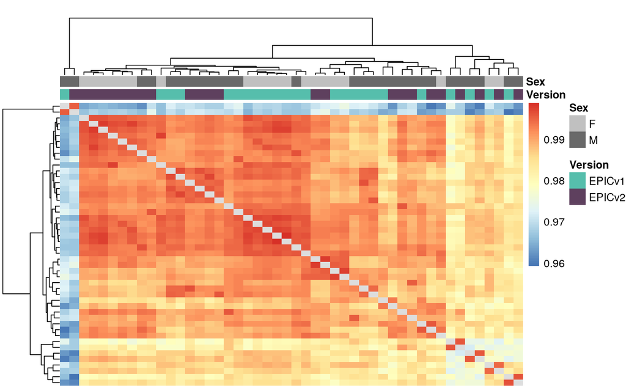

```r
# Specify colors
ann_colors = list(Sex =c(F="#C0C0C0", M ="#696969"),
    Version = c(EPICv1 = "#56BEAC", EPICv2 = "#5E405E"))


## heatmap for Pearson correlation + clustering
i <- which(sample_correlation_pearson == 1)
sample_correlation_pearson[i] <- NA

pheatmap(sample_correlation_pearson, cluster_rows=T, cluster_cols=T,
         clustering_distance_rows = "euclidean",
         clustering_distance_cols = "euclidean", clustering_method = "complete",
         annotation_col = color_pDat,
         annotation_colors = ann_colors,
         show_rownames = F, show_colnames = F,border_color = NA,
         main = '')
```

### 1.2.2 option 2. using Spearman correlation as input

```r
library(pheatmap)
library(RColorBrewer)

color_pDat <- SampleInfo %>% select(Version,Sex) %>% as.data.frame()
rownames(color_pDat) <- SampleInfo$Sample_Name

identical(rownames(color_pDat), colnames(sample_correlation_spearman)) # must match
```

```
## [1] TRUE
```

```r
str(color_pDat)
```

```
## 'data.frame':    48 obs. of  2 variables:
##  $ Version: chr  "EPICv1" "EPICv1" "EPICv1" "EPICv1" ...
##  $ Sex    : Factor w/ 2 levels "F","M": 2 1 2 1 2 2 1 1 2 2 ...
```

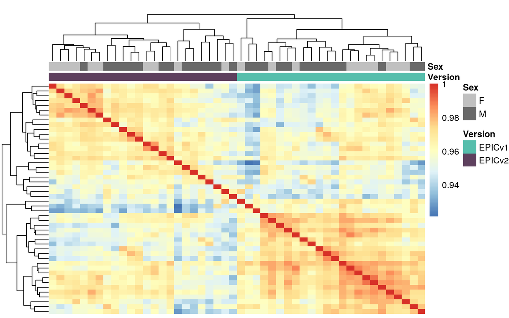

```r
# Specify colors
ann_colors = list(Sex =c(F="#C0C0C0", M ="#696969"),
    Version = c(EPICv1 = "#56BEAC", EPICv2 = "#5E405E"))


## heatmap for Pearson correlation + clustering
i <- which(sample_correlation_spearman == 1)
sample_correlation_pearson[i] <- NA

pheatmap(sample_correlation_spearman, cluster_rows=T, cluster_cols=T,
         clustering_distance_rows = "euclidean",
         clustering_distance_cols = "euclidean", clustering_method = "complete",
         annotation_col = color_pDat,
         annotation_colors = ann_colors,
         show_rownames = F, show_colnames = F,border_color = NA,
         main = '')
```

# 2 probe-level Spearman correlations, RMSE, and pooled SD

```r
# modifying the rmse function to remove NAs
rmse2 <- function(x, y, na.rm = TRUE){
    res <- sqrt(mean((x-y)^2, na.rm = na.rm))
    return(res)
}

j=1:nrow(EPICv1_beta_matrix)
# EPICv1 v2 beta matrix must have the same row order of common CpGs
probe_spearman_cor <- sapply(j, function(i) cor(EPICv1_beta_matrix[i,], EPICv2_beta_matrix[i,], method = "spearman"))
probe_rmse <- sapply(j, function(i) rmse2(EPICv1_beta_matrix[i,], EPICv2_beta_matrix[i,]))
probe_pooled_SD <- sapply(j, function(i) effectsize::sd_pooled(EPICv1_beta_matrix[i,], EPICv2_beta_matrix[i,]))
```

# 3 technical replicate ICC calculation (array-level)

I’m calculating ICCs for technical replicates within each EPIC version (EPICv1 tech rep ICC) technical replicates within EPIC version are the raters (column), and each probe is an item (row)  
1. within EPICv1 tech rep 2. between version tech reps (by mean)

We use ICC2 as the results

```r
library(psych)


# use one of the two pairs of technical replicate
tech_rep_v1 <- c("12294-V_v1", "12294-V_rep_v1")

## within EPICv1 technical replicate ICCs
input_data_EPICv1 <- data.frame(v= EPICv1_beta_matrix[, tech_rep_v1[1]],v_rep= EPICv1_beta_matrix[,tech_rep_v1[2]])
within_EPICv1_tech_rep_ICC <- psych::ICC(input_data_EPICv1) #use ICC2

## within EPICv2 technical replicate ICCs
tech_rep_v2 <- c("12294-V_v2", "12294-V_rep_v2")
input_data_EPICv2 <- data.frame(v= EPICv2_beta_matrix[, tech_rep_v2[1]],v_rep= EPICv2_beta_matrix[,tech_rep_v2[2]])
within_EPICv2_tech_rep_ICC <- psych::ICC(input_data_EPICv2) #use ICC2

## between EPICv1 and EPICv2 technical replicate ICCs
input_data <- data.frame(v1= EPICv1_beta_matrix[, tech_rep_v1] %>% rowMeans(),v2= EPICv2_beta_matrix[,tech_rep_v2]%>% rowMeans())
between_version_tech_rep_ICC <- psych::ICC(input_data) #use ICC2
```

# 4 Epigenetic age acceleration (EAA) calcualtion

## 4.1 1. EPIC version separate

we separated epigenetic ages of EPICv1 and EPICv2 samples and then calculated EAA independently on EPICv1 and EPICv2 samples by extracting residuals from the linear regression model: Epigenetic age ~ chronological age.

```r
# for each version separate
model_EEAA_EPICv1 = lm(Horvath_pantissue~ Age, data = EPICv1_clocks)
acc_residual_EEAA_EPICv1 <- model_EEAA_EPICv1$residuals


model_EEAA_EPICv2 = lm(Horvath_pantissue~ Age, data = EPICv2_clocks)
acc_residual_EEAA_EPICv2 <- model_EEAA_EPICv2$residuals
```

## 4.2 2. EPIC versions combined

we first combined epigenetic ages of EPICv1 and EPICv2 samples and then calculated EAA by extracting residuals from the linear regression model: Epigenetic age ~ chronological age.

```r
model_EEAA_combined = lm(Horvath_pantissue~ Age, data = rbind(EPICv1_clocks, EPICv2_clocks))
acc_residual_EEAA_combined <- model_EEAA_combined$residuals
acc_residual_EEAA_combined
```

```
##           1           2           3           4           5           6
##  0.08874764  2.56241032 -1.31614063  2.21230264 -7.22690192  8.30298172
##           7           8           9          10          11          12
##  1.70213467 -9.80818399 -2.88690814 -7.28886930  0.92842902 -7.51260363
##          13          14          15          16          17          18
## -1.50093554  7.86711192 -2.55171143 -0.80678545 -0.01159458 -5.64787098
##          19          20          21          22          23          24
##  2.16937661  4.66114234  2.73519598 -7.66685715  6.64223832  4.28998992
##          25          26          27          28          29          30
##  2.17911630  0.86717866 -6.89192148  5.21714243 -7.52931547 14.52639873
##          31          32          33          34          35          36
##  5.98719373 -6.24579470 -4.60973783 -1.85479513  2.44539300 -7.72056640
##          37          38          39          40          41          42
##  0.42874224  5.66964249 -9.17875323  1.69774798  0.31124609 -6.47559297
##          43          44          45          46          47          48
##  0.25613007  6.68929653  6.17718953 -6.45304275  6.04601846  8.52438536
```

## 4.3 3. EPIC versions combined and version adjusted:

we first combined epigenetic ages of EPICv1 and EPICv2 samples and calculated EAA by extracting residuals from the linear regression model: Epigenetic age ~ chronological age + EPIC version.

```r
model_EEAA_combined_adjusted = lm(Horvath_pantissue~ Age + Version, data = rbind(EPICv1_clocks, EPICv2_clocks))
acc_residual_EEAA_combined_adjusted <- model_EEAA_combined_adjusted$residuals
acc_residual_EEAA_combined_adjusted
```

```
##            1            2            3            4            5            6
##  0.508051871  2.981714558 -0.896836396  2.631606879 -6.807597687  8.722285954
##            7            8            9           10           11           12
##  2.121438907 -9.388879760 -2.467603909 -6.869565064  1.347733257 -7.093299399
##           13           14           15           16           17           18
## -1.081631303  8.286416156 -2.132407193 -0.387481215  0.407709652 -5.228566743
##           19           20           21           22           23           24
##  2.588680846  5.080446575  3.154500214 -7.247552910  7.061542556  4.709294152
##           25           26           27           28           29           30
##  1.759812068  0.447874427 -7.311225714  4.797838195 -7.948619705 14.107094498
##           31           32           33           34           35           36
##  5.567889493 -6.665098932 -5.029042063 -2.274099367  2.026088765 -8.139870633
##           37           38           39           40           41           42
##  0.009438006  5.250338253 -9.598057467  1.278443746 -0.108058142 -6.894897205
##           43           44           45           46           47           48
## -0.163174163  6.269992292  5.757885292 -6.872346987  5.626714222  8.105081121
```

# 5 EPIC version adjusted DunedinPACE, DNAmTL, epiTOC, and DNA methylation-based inflammation, smoking, and alcohol scores

## 5.1 1. EPIC version separate:

DunedinPACe, DNAmTL, epiTOC, and predictor estimates were calculated for EPICv1 and EPICv2 samples without EPIC version adjustment. These are the calculation from each clock/predictor. No additional calculation needed.

```r
input_estimates <- rbind(EPICv1_clocks, EPICv2_clocks) # combine EPICv1 and v2
non_adj_DunedinPACE <- input_estimates$DunedinPACE

non_adj_DunedinPACE
```

```
##  [1] 1.047465 1.070400 1.223401 1.119678 1.028975 1.313883 1.019157 1.199288
##  [9] 1.360565 1.209238 1.145832 1.054880 1.408234 1.137551 1.130147 1.288431
## [17] 1.109903 1.047729 1.128429 1.165152 1.379210 1.013673 1.382397 1.048882
## [25] 1.114245 1.130199 1.297683 1.235856 1.126137 1.385871 1.134649 1.241826
## [33] 1.432176 1.237011 1.156545 1.118734 1.415027 1.241682 1.188684 1.280454
## [41] 1.149375 1.160770 1.096184 1.282260 1.492669 1.089267 1.375068 1.066493
```

## 5.2 2. EPIC versions combined and version adjusted:

DunedinPACe, DNAmTL, epiTOC, and predictor estimates were first calculated for EPICv1 and EPICv2 samples, and were subsequently adjusted for EPIC versions by regressing out EPIC versions using linear regression model: Rate estimate ~ EPIC version.

```r
# DunedinPACE as example
input_estimates <- rbind(EPICv1_clocks, EPICv2_clocks) # combine EPICv1 and v2

model_predictor = lm(DunedinPACE ~ Version, data = input_estimates) # adjust Version
adj_DunedinPACE <- residuals(model_predictor)+mean(input_estimates$DunedinPACE)
adj_DunedinPACE
```

```
##        1        2        3        4        5        6        7        8
## 1.076973 1.099907 1.252909 1.149185 1.058482 1.343390 1.048665 1.228795
##        9       10       11       12       13       14       15       16
## 1.390072 1.238745 1.175340 1.084388 1.437742 1.167059 1.159655 1.317939
##       17       18       19       20       21       22       23       24
## 1.139411 1.077237 1.157937 1.194659 1.408718 1.043181 1.411905 1.078390
##       25       26       27       28       29       30       31       32
## 1.084738 1.100691 1.268175 1.206348 1.096629 1.356363 1.105142 1.212318
##       33       34       35       36       37       38       39       40
## 1.402668 1.207504 1.127038 1.089226 1.385520 1.212175 1.159177 1.250947
##       41       42       43       44       45       46       47       48
## 1.119867 1.131263 1.066676 1.252752 1.463162 1.059759 1.345561 1.036986
```

```r
EPICv1_clocks$adj_DunedinPACE <- adj_DunedinPACE[1:24]
EPICv2_clocks$adj_DunedinPACE <- adj_DunedinPACE[25:48]
```

# 6 Paired t tests and calculate effect size

```r
# remove technical replicates before t-tests
EPICv1_clocks_no_rep <-EPICv1_clocks %>% filter(!grepl("rep", Sample_Name, ignore.case = T))
EPICv2_clocks_no_rep <-EPICv2_clocks %>% filter(!grepl("rep", Sample_Name, ignore.case = T))


## example 1. DunedinPACE without EPIC version adjustment----
t.test(EPICv1_clocks_no_rep$DunedinPACE, EPICv2_clocks_no_rep$DunedinPACE,
            paired = T, alternative = "two.sided")
```

```
##
##  Paired t-test
##
## data:  EPICv1_clocks_no_rep$DunedinPACE and EPICv2_clocks_no_rep$DunedinPACE
## t = -6.2072, df = 21, p-value = 3.706e-06
## alternative hypothesis: true mean difference is not equal to 0
## 95 percent confidence interval:
##  -0.07783087 -0.03876690
## sample estimates:
## mean difference
##     -0.05829889
```

```r
library(effsize)
effsize::cohen.d(EPICv1_clocks_no_rep$DunedinPACE,
                    EPICv2_clocks_no_rep$DunedinPACE,
                    paired=T) # cohens'D must be paired
```

```
##
## Cohen's d
##
## d estimate: -0.4584747 (small)
## 95 percent confidence interval:
##      lower      upper
## -0.6151708 -0.3017786
```

```r
## example 2. DunedinPACE without EPIC version adjustment----
t.test(EPICv1_clocks_no_rep$adj_DunedinPACE, EPICv2_clocks_no_rep$adj_DunedinPACE,
            paired = T, alternative = "two.sided")
```

```
##
##  Paired t-test
##
## data:  EPICv1_clocks_no_rep$adj_DunedinPACE and EPICv2_clocks_no_rep$adj_DunedinPACE
## t = 0.076265, df = 21, p-value = 0.9399
## alternative hypothesis: true mean difference is not equal to 0
## 95 percent confidence interval:
##  -0.01881570  0.02024827
## sample estimates:
## mean difference
##    0.0007162876
```

```r
effsize::cohen.d(EPICv1_clocks_no_rep$adj_DunedinPACE,
                    EPICv2_clocks_no_rep$adj_DunedinPACE,
                    paired=T)
```

```
##
## Cohen's d
##
## d estimate: 0.005633036 (negligible)
## 95 percent confidence interval:
##      lower      upper
## -0.1434269  0.1546930
```